# R Accessing Data through APIs

Like everything in R, there are multiple ways to access data via APIs. Below are several examples that illustrate different services as well as different approaches/packages for data access.

## Accessing spatial data for points

A common task in ecological research is to get some spatial attribute like elevation or soil unit for a handful of points. This can be a real drag if you have to find, download, and assemble all of the base datasets before you can retrieve the attribute of interest. APIs are a good solution for this case. You can pass point locations to the API and return the data values. Two examples below are querying USGS National Elevation Dataset DEMs. The USGS API is “documented” [here, really sucky documentation](http://ned.usgs.gov/epqs/).

1. Here’s the basic structure of the API call with a fixed query (XML result)

```r
print(elev)
```

```
[1] 354.85
```

2. Well, that’s a start. It definitely works. Now let’s get the values for a set of points.

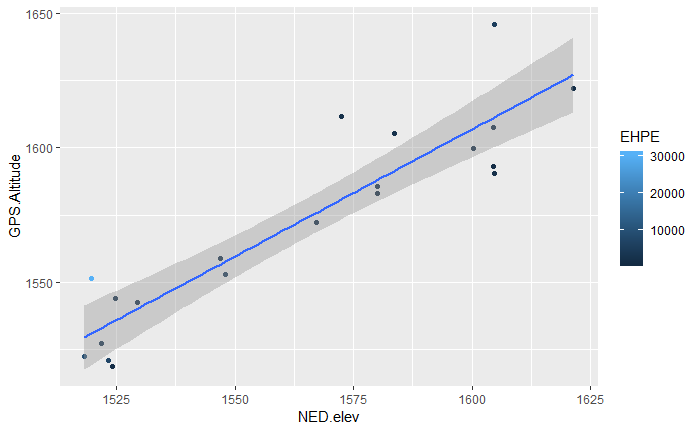

3. Of course, there’s a library that pulls elevation data for you easily.

|  | Index | Date | Time | Altitude | EHPE | elevation | elev_units |
| --- | --- | --- | --- | --- | --- | --- | --- |
| 5990 | 8573 | 2017/08/12 | 22:46:55 | 1599.81 | 1504 | 1600.34 | meters |
| 5684 | 8267 | 2017/08/12 | 03:29:58 | 1585.77 | 2512 | 1579.97 | meters |
| 10964 | 13547 | 2017/08/26 | 05:57:12 | 1553.02 | 4960 | 1548.06 | meters |
| 7708 | 10291 | 2017/08/17 | 10:58:12 | 1645.81 | 5664 | 1604.73 | meters |
| 2225 | 4808 | 2017/08/02 | 16:37:48 | 1542.74 | 2272 | 1529.33 | meters |
| 2156 | 4739 | 2017/08/02 | 12:07:45 | 1518.69 | 1968 | 1524.15 | meters |
| 197 | 2780 | 2017/07/28 | 05:51:59 | 1521.17 | 7440 | 1523.41 | meters |
| 7237 | 9820 | 2017/08/16 | 05:43:09 | 1607.55 | 1520 | 1604.52 | meters |
| 11443 | 14026 | 2017/08/27 | 13:02:14 | 1572.14 | 1616 | 1567.09 | meters |
| 466 | 3049 | 2017/07/28 | 22:55:03 | 1522.57 | 9712 | 1518.35 | meters |

[output cut: 10 more lines]

## Accessing biodiversity records from GBIF

The Global Biodiversity Information Facility (GBIF) maintains a global biodiversity database of species occurrence records. You can query their API for things like locations of a species. They have pretty good API documentation that can be found at https://www.gbif.org/developer/summary.

Let’s grab the occurrence records for *Clarkia pulchella*, large-flower Clarkia, a plant first discovered on the Lewis & Clark expidition near Kamiah, Idaho ([Wikipedia Page](https://en.wikipedia.org/wiki/Clarkia_pulchella)). We’ll make a map of the occurrence records. This example will illustrate an approach to pagination.

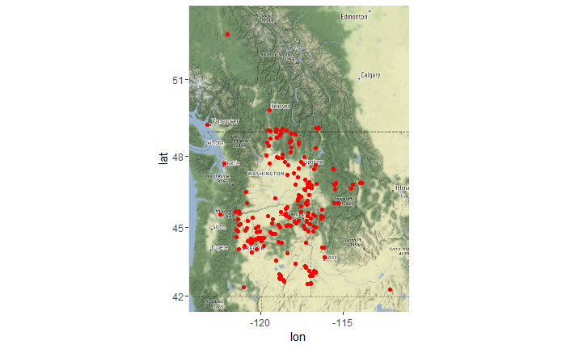

## Some useful resources

- [Getting started with httr guide](https://cran.r-project.org/web/packages/httr/vignettes/quickstart.html)
- [Fetching JSON data from Rest APIs](https://cran.r-project.org/web/packages/jsonlite/vignettes/json-apis.html) - examples of different API and authentication formats.
- [accessing RESTful APIs using R](https://www.programmableweb.com/news/how-to-access-any-restful-api-using-r-language/how-to/2017/07/21)